# Encuesta de Satisfacción Estudiantil

Análisis descriptivo: Perfil y percepción de la calidad educativa

Autor/a

Ulises Rodas

Fecha de publicación

28 de abril de 2026

# 1 Introducción

El presente informe consolida los resultados del levantamiento de información realizado a los estudiantes de la facultad de Ciencias Sociales UNMSM. El objetivo es **diagnosticar el estado actual de la** **satisfacción** en tres dimensiones: Plan de Estudios, Infraestructura y Oportunidades Laborales.

Los datos presentados a continuación provienen de una base depurada y validada, garantizando la consistencia estadística. **Los resultados se dividen en tres bloques:**

1. **Perfil** **del estudiante:** Se presentan las características inherentes a los integrantes de la facultad, como son Sexo, Nivel curricular cursado y Carrera elegida.
2. **Satisfacción del estudiante:** Valoración de los servicios de la facultad (Plan de estudios, Infraestrucutra y Oportunidades laborales)
3. **¿Por qué hay insatisfacción con los servicios?:** Se presenta como complemento a lo anterior. Aquí veremos las respuestas más frecuentes de por qué no están satisfechos los estudiantes con los servicios ofrecidos. Desde luego, esta insatisfacción tiene un sesgo negativo dado que solo analiza a los insatisfechos, pero da un excelente feedback a la facultad para saber áreas de mejoría.

# 2 Perfil del estudiante

La muestra recolectada abarca diversos perfiles demográficos y académicos, asegurando representatividad. Veamos algunos gráficos para explorar la composición de los estudiantes.

## 2.1 Sexo

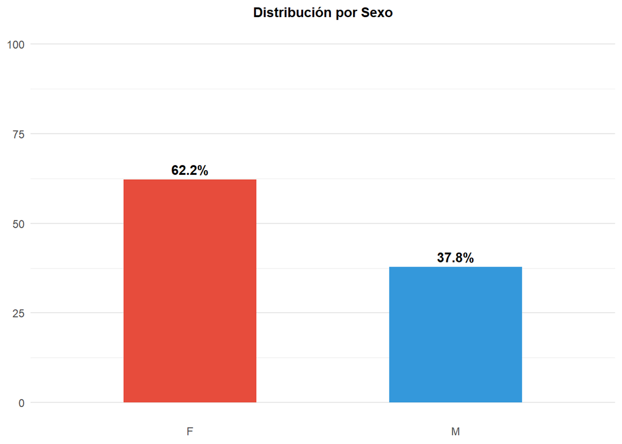

```r
g_sexo
```

## 2.2 Nivel curricular

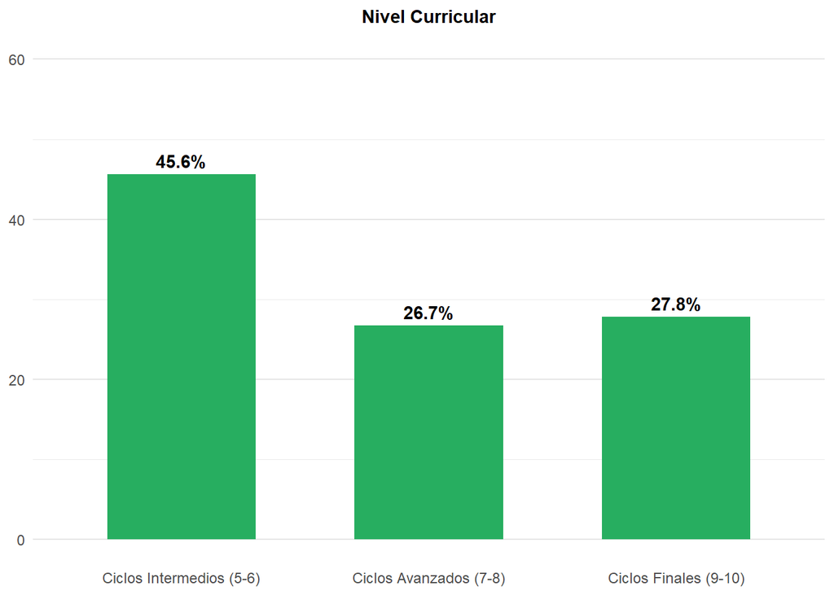

```r
g_nivel
```

## 2.3 Carreras

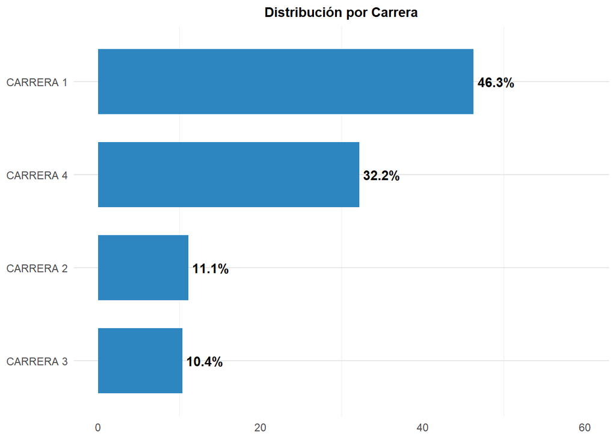

```r
g_carrera
```

## 2.4 **Interpretación del Perfil de la Muestra**

La muestra analizada ($n=270$) presenta una composición demográfica predominantemente **femenina (62.2%)**. Respecto al **nivel curricular**, el estudio logra representatividad en todas las etapas formativas. Si bien el grupo mayoritario corresponde a los **Ciclos Intermedios (45.6%)**, existe una aceptable participación de estudiantes de ciclos avanzados y finales, lo que permite contrastar la visión del estudiante en proceso frente a la del estudiante próximo a egresar.

Finalmente, en cuanto a la distribución académica, se observa una concentración significativa en la **Carrera 1**, que agrupa al **46.3%** de los encuestados, seguida por la Carrera 4 (32.2%); esto sugiere que los resultados generales del estudio estarán fuertemente influenciados por la experiencia educativa de estas dos escuelas principales.

# 3 Satisfacción del estudiante

## 3.1 Plan de estudios

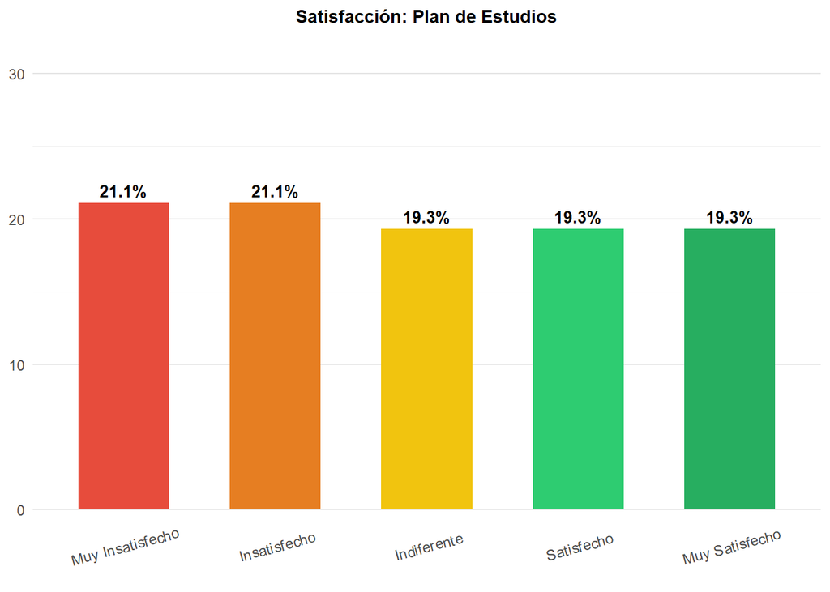

```r
g_sat_plan
```

## 3.2 Infraestructura

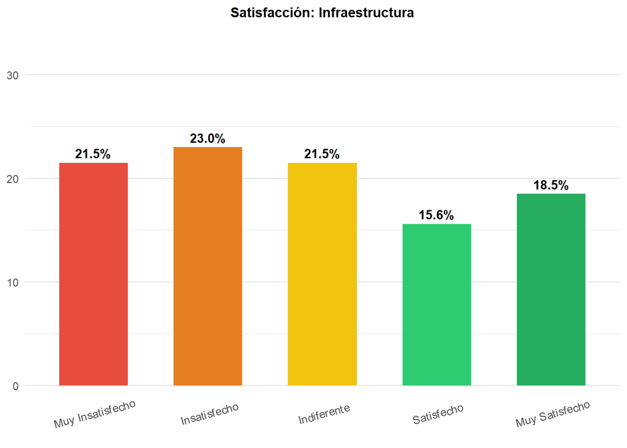

```r
g_sat_infra
```

## 3.3 Oportunidades laborales

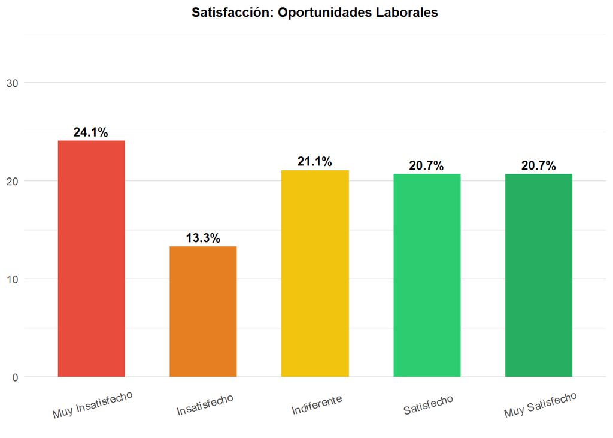

```r
g_sat_laboral
```

## 3.4 Interpretación

A partir del análisis descriptivo de la muestra ($n=270$), se derivan las siguientes conclusiones estratégicas para la gestión de la Facultad:

1. **Polarización académica y actualización:**

   La evaluación del **Plan de Estudios** revela una división marcada en el estudiantado. Con un **42.2% de insatisfacción** (sumatoria de *Insatisfecho* y *Muy Insatisfecho*), existe una señal clara de alerta. Los resultados apuntan a la necesidad de revisar la vigencia de las mallas curriculares, pues una parte significativa del alumnado percibe una desconexión entre los contenidos impartidos y las exigencias actuales.
2. **Prioridad crítica en Infraestructura:**

   La dimensión de **Infraestructura** presenta los indicadores más alarmantes, con un **44.5% de los estudiantes insatisfechos** (sumatoria de *Insatisfecho* y *Muy Insatisfecho*). La evidencia sugiere que la carencia de espacios adecuados de estudio y laboratorios está impactando negativamente la experiencia universitaria diaria. Se recomienda priorizar la inversión en mantenimiento y habilitación de espacios a corto plazo.
3. **Desafío en empleabilidad:**

   La percepción sobre **Oportunidades Laborale**s refleja incertidumbre y descontento (**37.4% de insatisfacción** y **21.1% de indiferencia**). Esta percepción negativa sugiere la urgencia de fortalecer la oficina de bolsa de trabajo y generar nuevos convenios de prácticas pre-profesionales para mejorar la inserción laboral de los egresados.

# 4 ¿Por qué hay insatisfacción con los servicios?

## 4.1 Plan de estudios

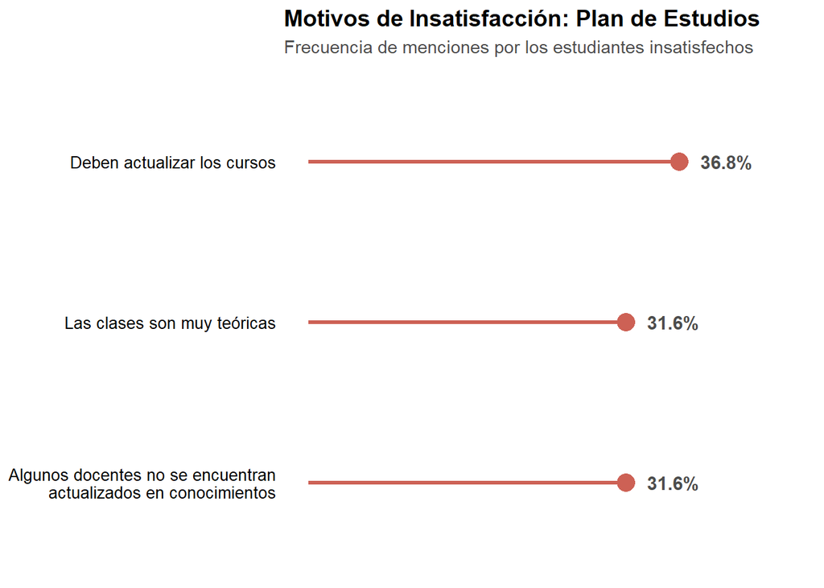

```r
g_motivo_plan
```

## 4.2 Infraestructura

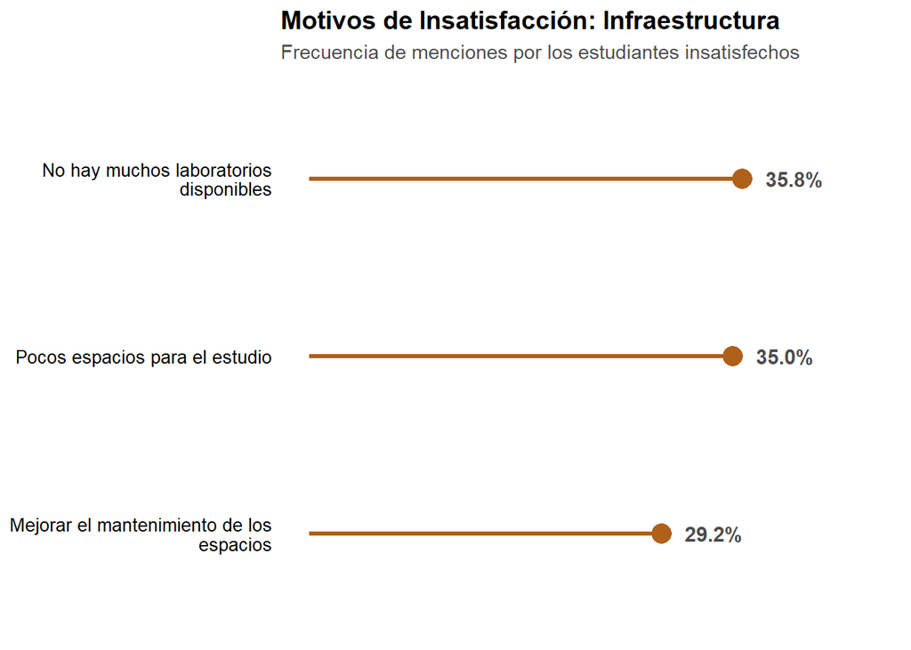

```r
g_motivo_infra
```

## 4.3 Oportunidades laborales

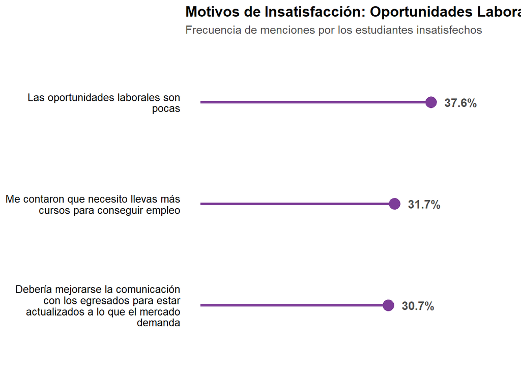

```r
g_motivo_laboral
```

## 4.4 Interpretación

Al desagregar las respuestas de los estudiantes que manifestaron insatisfacción (1 y 2), se identificaron patrones claros que explican la problemática en cada dimensión:

- **Plan de Estudios (Brecha Teórico-Práctica):** La queja predominante, “*Actualizar los cursos*”, revela una demanda por obtener mayores conocimientos y más actuales, sintiendo que se quedan desfazados frente a las nuevas tecnologías o tendencias. Por otro lado, *“Las clases son muy teóricas”*, revela la necesidad de metodologías más aplicadas.
- **Infraestructura (Déficit de Espacios):** Los reclamos se concentran en aspectos tangibles y funcionales. La *“Falta de laboratorios disponibles”* y los *“Pocos espacios para el estudio”* son los motivos recurrentes. Esto indica que la infraestructura actual no está soportando adecuadamente la vida académica fuera del aula, limitando el trabajo autónomo y la investigación.
- **Oportunidades Laborales (Desconexión con el Mercado):** Existe una crítica estructural hacia la gestión de la empleabilidad. Los estudiantes señalan que *“Las oportunidades laborales son pocas”* y demandan explícitamente *“Mejorar la comunicación con los egresados”*. Esto evidencia una percepción de aislamiento: el alumno siente que la facultad no está tendiendo los puentes necesarios con el mercado laboral real ni aprovechando su red de exalumnos (alumni).